# Risk Factor Analysis

## Outcome Variable

**Outcome Variable:** whz

## Predictor Variables

**Intervention Variable:** mwtkg

**Adjustment Set:**

- arm
- W_mage
- W_fage
- meducyrs
- feducyrs
- single
- brthmon
- W_gagebrth
- W_birthwt
- W_birthlen
- vagbrth
- delta_W_mage
- delta_W_fage
- delta_meducyrs
- delta_feducyrs
- delta_single
- delta_brthmon
- delta_W_gagebrth
- delta_W_birthwt
- delta_W_birthlen
- delta_vagbrth

## Stratifying Variables

The analysis was stratified on these variable(s):

- agecat
- studyid
- country

## Data Summary

| agecat | studyid | country | mwtkg | n_cell | n |
| --- | --- | --- | --- | --- | --- |
| 6 months | ki0047075b-MAL-ED | BANGLADESH | >=58 kg | 46 | 241 |
| 6 months | ki0047075b-MAL-ED | BANGLADESH | <52 kg | 154 | 241 |
| 6 months | ki0047075b-MAL-ED | BANGLADESH | [52-58) kg | 41 | 241 |
| 6 months | ki0047075b-MAL-ED | BRAZIL | >=58 kg | 137 | 208 |
| 6 months | ki0047075b-MAL-ED | BRAZIL | <52 kg | 37 | 208 |
| 6 months | ki0047075b-MAL-ED | BRAZIL | [52-58) kg | 34 | 208 |
| 6 months | ki0047075b-MAL-ED | INDIA | >=58 kg | 40 | 235 |
| 6 months | ki0047075b-MAL-ED | INDIA | <52 kg | 146 | 235 |
| 6 months | ki0047075b-MAL-ED | INDIA | [52-58) kg | 49 | 235 |
| 6 months | ki0047075b-MAL-ED | NEPAL | >=58 kg | 79 | 236 |
| 6 months | ki0047075b-MAL-ED | NEPAL | <52 kg | 75 | 236 |
| 6 months | ki0047075b-MAL-ED | NEPAL | [52-58) kg | 82 | 236 |
| 6 months | ki0047075b-MAL-ED | PERU | >=58 kg | 100 | 272 |
| 6 months | ki0047075b-MAL-ED | PERU | <52 kg | 107 | 272 |
| 6 months | ki0047075b-MAL-ED | PERU | [52-58) kg | 65 | 272 |
| 6 months | ki0047075b-MAL-ED | SOUTH AFRICA | >=58 kg | 179 | 249 |
| 6 months | ki0047075b-MAL-ED | SOUTH AFRICA | <52 kg | 29 | 249 |
| 6 months | ki0047075b-MAL-ED | SOUTH AFRICA | [52-58) kg | 41 | 249 |
| 6 months | ki0047075b-MAL-ED | TANZANIA, UNITED REPUBLIC OF | >=58 kg | 94 | 247 |
| 6 months | ki0047075b-MAL-ED | TANZANIA, UNITED REPUBLIC OF | <52 kg | 95 | 247 |
| 6 months | ki0047075b-MAL-ED | TANZANIA, UNITED REPUBLIC OF | [52-58) kg | 58 | 247 |
| 6 months | ki1000304b-SAS-CompFeed | INDIA | >=58 kg | 99 | 1328 |
| 6 months | ki1000304b-SAS-CompFeed | INDIA | <52 kg | 1016 | 1328 |
| 6 months | ki1000304b-SAS-CompFeed | INDIA | [52-58) kg | 213 | 1328 |
| 6 months | ki1017093-NIH-Birth | BANGLADESH | >=58 kg | 71 | 536 |
| 6 months | ki1017093-NIH-Birth | BANGLADESH | <52 kg | 384 | 536 |
| 6 months | ki1017093-NIH-Birth | BANGLADESH | [52-58) kg | 81 | 536 |
| 6 months | ki1017093b-PROVIDE | BANGLADESH | >=58 kg | 106 | 581 |
| 6 months | ki1017093b-PROVIDE | BANGLADESH | <52 kg | 369 | 581 |
| 6 months | ki1017093b-PROVIDE | BANGLADESH | [52-58) kg | 106 | 581 |

[output cut: 57 more lines]

The following strata were considered:

- agecat: 24 months, studyid: ki0047075b-MAL-ED, country: BANGLADESH
- agecat: 24 months, studyid: ki0047075b-MAL-ED, country: BRAZIL
- agecat: 24 months, studyid: ki0047075b-MAL-ED, country: INDIA
- agecat: 24 months, studyid: ki0047075b-MAL-ED, country: NEPAL
- agecat: 24 months, studyid: ki0047075b-MAL-ED, country: PERU
- agecat: 24 months, studyid: ki0047075b-MAL-ED, country: SOUTH AFRICA
- agecat: 24 months, studyid: ki0047075b-MAL-ED, country: TANZANIA, UNITED REPUBLIC OF
- agecat: 24 months, studyid: ki1017093-NIH-Birth, country: BANGLADESH
- agecat: 24 months, studyid: ki1017093b-PROVIDE, country: BANGLADESH
- agecat: 24 months, studyid: ki1017093c-NIH-Crypto, country: BANGLADESH
- agecat: 24 months, studyid: ki1066203-TanzaniaChild2, country: TANZANIA, UNITED REPUBLIC OF
- agecat: 24 months, studyid: ki1119695-PROBIT, country: BELARUS
- agecat: 24 months, studyid: ki1126311-ZVITAMBO, country: ZIMBABWE
- agecat: 24 months, studyid: ki1148112-LCNI-5, country: MALAWI
- agecat: 6 months, studyid: ki0047075b-MAL-ED, country: BANGLADESH
- agecat: 6 months, studyid: ki0047075b-MAL-ED, country: BRAZIL
- agecat: 6 months, studyid: ki0047075b-MAL-ED, country: INDIA
- agecat: 6 months, studyid: ki0047075b-MAL-ED, country: NEPAL
- agecat: 6 months, studyid: ki0047075b-MAL-ED, country: PERU
- agecat: 6 months, studyid: ki0047075b-MAL-ED, country: SOUTH AFRICA
- agecat: 6 months, studyid: ki0047075b-MAL-ED, country: TANZANIA, UNITED REPUBLIC OF
- agecat: 6 months, studyid: ki1000304b-SAS-CompFeed, country: INDIA
- agecat: 6 months, studyid: ki1017093-NIH-Birth, country: BANGLADESH
- agecat: 6 months, studyid: ki1017093b-PROVIDE, country: BANGLADESH
- agecat: 6 months, studyid: ki1017093c-NIH-Crypto, country: BANGLADESH
- agecat: 6 months, studyid: ki1066203-TanzaniaChild2, country: TANZANIA, UNITED REPUBLIC OF
- agecat: 6 months, studyid: ki1119695-PROBIT, country: BELARUS
- agecat: 6 months, studyid: ki1126311-ZVITAMBO, country: ZIMBABWE
- agecat: 6 months, studyid: ki1148112-LCNI-5, country: MALAWI

### Dropped Strata

Some strata were dropped due to rare outcomes:

- agecat: 24 months, studyid: ki1066203-TanzaniaChild2, country: TANZANIA, UNITED REPUBLIC OF

## Methods Detail

We’re interested in the causal parameters $E[Y_a]$ for all values of $a \in \mathcal{A}$. These parameters represent the mean outcome if, possibly contrary to fact, we intervened to set all units to have $A=a$. Under the randomization and positivity assumptions, these are identified by the statistical parameters $\psi_a=E_W[E_{Y|A,W}(Y|A=a,W)]$. In addition, we’re interested in the mean of $Y$, $E[Y]$ under no intervention (the observed mean). We will estimate these parameters by using SuperLearner to fit the relevant likelihood factors – $E_{Y|A,W}(Y|A=a,W)$ and $p(A=a|W)$, and then updating our likelihood fit using a joint TMLE.

For unadjusted analyses ($W=\{\}$), initial likelihoods were estimated using Lrnr_glm to estimate the simple $E(Y|A)$ and Lrnr_mean to estimate $p(A)$. For adjusted analyses, a small library containing Lrnr_glmnet, Lrnr_xgboost, and Lrnr_mean was used.

Having estimated these parameters, we will then use the delta method to estimate relative risks and attributable risks relative to a prespecified baseline level of $A$.

# Results Detail

## Results Plots

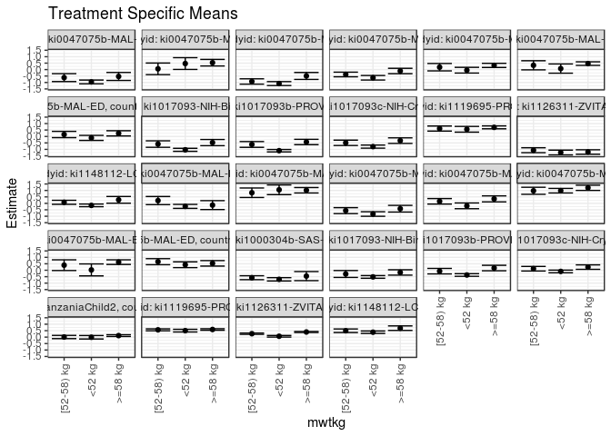

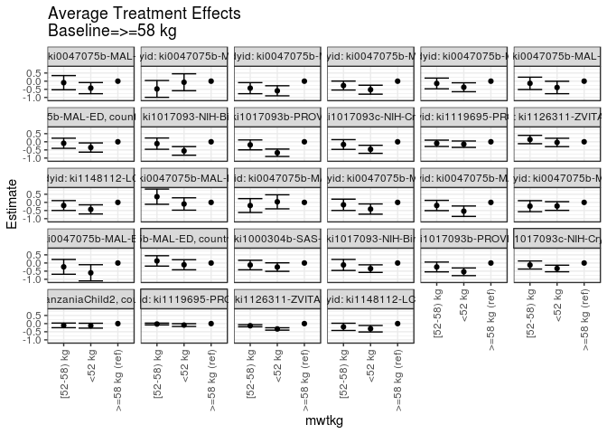

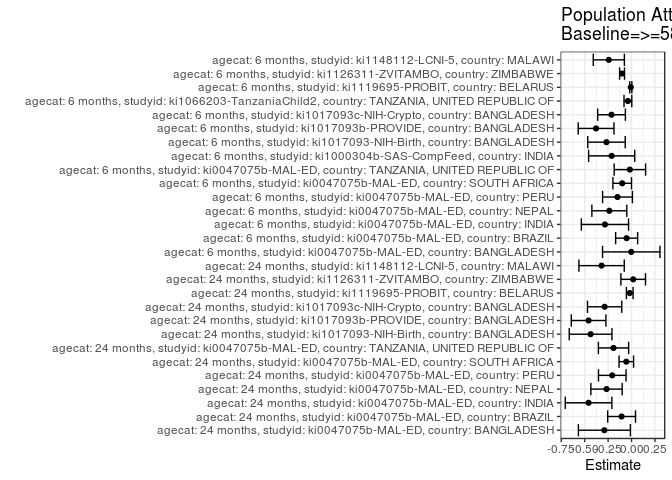

## Results Table

### Parameter: TSM

| agecat | studyid | country | intervention_level | baseline_level | estimate | ci_lower | ci_upper |
| --- | --- | --- | --- | --- | --- | --- | --- |
| 6 months | ki0047075b-MAL-ED | BANGLADESH | >=58 kg | NA | -0.1368801 | -0.4824261 | 0.2086659 |
| 6 months | ki0047075b-MAL-ED | BANGLADESH | <52 kg | NA | -0.2348095 | -0.3887207 | -0.0808984 |
| 6 months | ki0047075b-MAL-ED | BANGLADESH | [52-58) kg | NA | 0.2145349 | -0.1017231 | 0.5307929 |
| 6 months | ki0047075b-MAL-ED | BRAZIL | >=58 kg | NA | 1.0165710 | 0.8071773 | 1.2259647 |
| 6 months | ki0047075b-MAL-ED | BRAZIL | <52 kg | NA | 1.0523921 | 0.6763333 | 1.4284508 |
| 6 months | ki0047075b-MAL-ED | BRAZIL | [52-58) kg | NA | 0.8227882 | 0.4546892 | 1.1908872 |
| 6 months | ki0047075b-MAL-ED | INDIA | >=58 kg | NA | -0.4151162 | -0.6735457 | -0.1566867 |
| 6 months | ki0047075b-MAL-ED | INDIA | <52 kg | NA | -0.8256780 | -1.0028162 | -0.6485398 |
| 6 months | ki0047075b-MAL-ED | INDIA | [52-58) kg | NA | -0.5636117 | -0.7941835 | -0.3330399 |
| 6 months | ki0047075b-MAL-ED | NEPAL | >=58 kg | NA | 0.3479013 | 0.1168019 | 0.5790007 |
| 6 months | ki0047075b-MAL-ED | NEPAL | <52 kg | NA | -0.1933738 | -0.4163040 | 0.0295563 |
| 6 months | ki0047075b-MAL-ED | NEPAL | [52-58) kg | NA | 0.1575120 | -0.0565397 | 0.3715638 |
| 6 months | ki0047075b-MAL-ED | PERU | >=58 kg | NA | 1.2060718 | 1.0045505 | 1.4075931 |
| 6 months | ki0047075b-MAL-ED | PERU | <52 kg | NA | 0.9821341 | 0.8066524 | 1.1576158 |
| 6 months | ki0047075b-MAL-ED | PERU | [52-58) kg | NA | 0.9743038 | 0.7021281 | 1.2464795 |
| 6 months | ki0047075b-MAL-ED | SOUTH AFRICA | >=58 kg | NA | 0.6284611 | 0.4488672 | 0.8080551 |
| 6 months | ki0047075b-MAL-ED | SOUTH AFRICA | <52 kg | NA | 0.0241298 | -0.4391902 | 0.4874498 |
| 6 months | ki0047075b-MAL-ED | SOUTH AFRICA | [52-58) kg | NA | 0.3922297 | -0.0247094 | 0.8091689 |
| 6 months | ki0047075b-MAL-ED | TANZANIA, UNITED REPUBLIC OF | >=58 kg | NA | 0.5344640 | 0.3217959 | 0.7471321 |
| 6 months | ki0047075b-MAL-ED | TANZANIA, UNITED REPUBLIC OF | <52 kg | NA | 0.4262390 | 0.2012978 | 0.6511801 |
| 6 months | ki0047075b-MAL-ED | TANZANIA, UNITED REPUBLIC OF | [52-58) kg | NA | 0.6627446 | 0.4267848 | 0.8987044 |
| 6 months | ki1000304b-SAS-CompFeed | INDIA | >=58 kg | NA | -0.4554415 | -0.8076249 | -0.1032581 |
| 6 months | ki1000304b-SAS-CompFeed | INDIA | <52 kg | NA | -0.7051776 | -0.8330346 | -0.5773205 |
| 6 months | ki1000304b-SAS-CompFeed | INDIA | [52-58) kg | NA | -0.5811114 | -0.7337729 | -0.4284500 |
| 6 months | ki1017093-NIH-Birth | BANGLADESH | >=58 kg | NA | -0.1716373 | -0.3789812 | 0.0357067 |
| 6 months | ki1017093-NIH-Birth | BANGLADESH | <52 kg | NA | -0.5173258 | -0.6215205 | -0.4131312 |
| 6 months | ki1017093-NIH-Birth | BANGLADESH | [52-58) kg | NA | -0.2912892 | -0.5596421 | -0.0229363 |
| 6 months | ki1017093b-PROVIDE | BANGLADESH | >=58 kg | NA | 0.1703320 | -0.0423924 | 0.3830564 |
| 6 months | ki1017093b-PROVIDE | BANGLADESH | <52 kg | NA | -0.3692893 | -0.4701640 | -0.2684147 |
| 6 months | ki1017093b-PROVIDE | BANGLADESH | [52-58) kg | NA | -0.0725758 | -0.2868983 | 0.1417467 |

[output cut: 54 more lines]

### Parameter: E(Y)

| agecat | studyid | country | intervention_level | baseline_level | estimate | ci_lower | ci_upper |
| --- | --- | --- | --- | --- | --- | --- | --- |
| 6 months | ki0047075b-MAL-ED | BANGLADESH | NA | NA | -0.1397960 | -0.2688682 | -0.0107238 |
| 6 months | ki0047075b-MAL-ED | BRAZIL | NA | NA | 0.9644952 | 0.7999744 | 1.1290160 |
| 6 months | ki0047075b-MAL-ED | INDIA | NA | NA | -0.6987943 | -0.8241325 | -0.5734561 |
| 6 months | ki0047075b-MAL-ED | NEPAL | NA | NA | 0.1110452 | -0.0202712 | 0.2423616 |
| 6 months | ki0047075b-MAL-ED | PERU | NA | NA | 1.0563787 | 0.9342938 | 1.1784635 |
| 6 months | ki0047075b-MAL-ED | SOUTH AFRICA | NA | NA | 0.5290428 | 0.3750394 | 0.6830463 |
| 6 months | ki0047075b-MAL-ED | TANZANIA, UNITED REPUBLIC OF | NA | NA | 0.5170513 | 0.3872178 | 0.6468847 |
| 6 months | ki1000304b-SAS-CompFeed | INDIA | NA | NA | -0.6674586 | -0.8042294 | -0.5306877 |
| 6 months | ki1017093-NIH-Birth | BANGLADESH | NA | NA | -0.4389101 | -0.5279432 | -0.3498771 |
| 6 months | ki1017093b-PROVIDE | BANGLADESH | NA | NA | -0.2079891 | -0.2925599 | -0.1234183 |
| 6 months | ki1017093c-NIH-Crypto | BANGLADESH | NA | NA | 0.0297622 | -0.0491685 | 0.1086930 |
| 6 months | ki1066203-TanzaniaChild2 | TANZANIA, UNITED REPUBLIC OF | NA | NA | 0.0780261 | 0.0247830 | 0.1312691 |
| 6 months | ki1119695-PROBIT | BELARUS | NA | NA | 0.5834072 | 0.5254491 | 0.6413653 |
| 6 months | ki1126311-ZVITAMBO | ZIMBABWE | NA | NA | 0.2953392 | 0.2687669 | 0.3219114 |
| 6 months | ki1148112-LCNI-5 | MALAWI | NA | NA | 0.4518399 | 0.3806212 | 0.5230586 |
| 24 months | ki0047075b-MAL-ED | BANGLADESH | NA | NA | -0.8208255 | -0.9429246 | -0.6987264 |
| 24 months | ki0047075b-MAL-ED | BRAZIL | NA | NA | 0.4282738 | 0.2252365 | 0.6313111 |
| 24 months | ki0047075b-MAL-ED | INDIA | NA | NA | -0.9525664 | -1.0684455 | -0.8366872 |
| 24 months | ki0047075b-MAL-ED | NEPAL | NA | NA | -0.3764474 | -0.4898516 | -0.2630431 |
| 24 months | ki0047075b-MAL-ED | PERU | NA | NA | 0.1199005 | -0.0000331 | 0.2398341 |
| 24 months | ki0047075b-MAL-ED | SOUTH AFRICA | NA | NA | 0.4096154 | 0.2902946 | 0.5289362 |
| 24 months | ki0047075b-MAL-ED | TANZANIA, UNITED REPUBLIC OF | NA | NA | 0.0500935 | -0.0748234 | 0.1750103 |
| 24 months | ki1017093-NIH-Birth | BANGLADESH | NA | NA | -0.9115790 | -1.0095022 | -0.8136559 |
| 24 months | ki1017093b-PROVIDE | BANGLADESH | NA | NA | -0.8864991 | -0.9695215 | -0.8034768 |
| 24 months | ki1017093c-NIH-Crypto | BANGLADESH | NA | NA | -0.6103502 | -0.7050157 | -0.5156847 |
| 24 months | ki1119695-PROBIT | BELARUS | NA | NA | 0.6877387 | 0.5737746 | 0.8017027 |
| 24 months | ki1126311-ZVITAMBO | ZIMBABWE | NA | NA | -1.1865133 | -1.2873598 | -1.0856668 |
| 24 months | ki1148112-LCNI-5 | MALAWI | NA | NA | -0.0467082 | -0.1287046 | 0.0352882 |

### Parameter: ATE

| agecat | studyid | country | intervention_level | baseline_level | estimate | ci_lower | ci_upper |
| --- | --- | --- | --- | --- | --- | --- | --- |
| 6 months | ki0047075b-MAL-ED | BANGLADESH | >=58 kg | >=58 kg | 0.0000000 | 0.0000000 | 0.0000000 |
| 6 months | ki0047075b-MAL-ED | BANGLADESH | <52 kg | >=58 kg | -0.0979294 | -0.4767428 | 0.2808840 |
| 6 months | ki0047075b-MAL-ED | BANGLADESH | [52-58) kg | >=58 kg | 0.3514150 | -0.1164304 | 0.8192603 |
| 6 months | ki0047075b-MAL-ED | BRAZIL | >=58 kg | >=58 kg | 0.0000000 | 0.0000000 | 0.0000000 |
| 6 months | ki0047075b-MAL-ED | BRAZIL | <52 kg | >=58 kg | 0.0358210 | -0.3959901 | 0.4676322 |
| 6 months | ki0047075b-MAL-ED | BRAZIL | [52-58) kg | >=58 kg | -0.1937828 | -0.6201033 | 0.2325377 |
| 6 months | ki0047075b-MAL-ED | INDIA | >=58 kg | >=58 kg | 0.0000000 | 0.0000000 | 0.0000000 |
| 6 months | ki0047075b-MAL-ED | INDIA | <52 kg | >=58 kg | -0.4105618 | -0.7240149 | -0.0971087 |
| 6 months | ki0047075b-MAL-ED | INDIA | [52-58) kg | >=58 kg | -0.1484955 | -0.4951687 | 0.1981776 |
| 6 months | ki0047075b-MAL-ED | NEPAL | >=58 kg | >=58 kg | 0.0000000 | 0.0000000 | 0.0000000 |
| 6 months | ki0047075b-MAL-ED | NEPAL | <52 kg | >=58 kg | -0.5412751 | -0.8613007 | -0.2212495 |
| 6 months | ki0047075b-MAL-ED | NEPAL | [52-58) kg | >=58 kg | -0.1903893 | -0.5048837 | 0.1241051 |
| 6 months | ki0047075b-MAL-ED | PERU | >=58 kg | >=58 kg | 0.0000000 | 0.0000000 | 0.0000000 |
| 6 months | ki0047075b-MAL-ED | PERU | <52 kg | >=58 kg | -0.2239377 | -0.4903841 | 0.0425088 |
| 6 months | ki0047075b-MAL-ED | PERU | [52-58) kg | >=58 kg | -0.2317680 | -0.5692843 | 0.1057483 |
| 6 months | ki0047075b-MAL-ED | SOUTH AFRICA | >=58 kg | >=58 kg | 0.0000000 | 0.0000000 | 0.0000000 |
| 6 months | ki0047075b-MAL-ED | SOUTH AFRICA | <52 kg | >=58 kg | -0.6043314 | -1.1023955 | -0.1062672 |
| 6 months | ki0047075b-MAL-ED | SOUTH AFRICA | [52-58) kg | >=58 kg | -0.2362314 | -0.6914674 | 0.2190046 |
| 6 months | ki0047075b-MAL-ED | TANZANIA, UNITED REPUBLIC OF | >=58 kg | >=58 kg | 0.0000000 | 0.0000000 | 0.0000000 |
| 6 months | ki0047075b-MAL-ED | TANZANIA, UNITED REPUBLIC OF | <52 kg | >=58 kg | -0.1082250 | -0.4181174 | 0.2016673 |
| 6 months | ki0047075b-MAL-ED | TANZANIA, UNITED REPUBLIC OF | [52-58) kg | >=58 kg | 0.1282806 | -0.1895722 | 0.4461334 |
| 6 months | ki1000304b-SAS-CompFeed | INDIA | >=58 kg | >=58 kg | 0.0000000 | 0.0000000 | 0.0000000 |
| 6 months | ki1000304b-SAS-CompFeed | INDIA | <52 kg | >=58 kg | -0.2497360 | -0.5110818 | 0.0116097 |
| 6 months | ki1000304b-SAS-CompFeed | INDIA | [52-58) kg | >=58 kg | -0.1256699 | -0.4183825 | 0.1670427 |
| 6 months | ki1017093-NIH-Birth | BANGLADESH | >=58 kg | >=58 kg | 0.0000000 | 0.0000000 | 0.0000000 |
| 6 months | ki1017093-NIH-Birth | BANGLADESH | <52 kg | >=58 kg | -0.3456886 | -0.5782668 | -0.1131103 |
| 6 months | ki1017093-NIH-Birth | BANGLADESH | [52-58) kg | >=58 kg | -0.1196519 | -0.4590697 | 0.2197658 |
| 6 months | ki1017093b-PROVIDE | BANGLADESH | >=58 kg | >=58 kg | 0.0000000 | 0.0000000 | 0.0000000 |
| 6 months | ki1017093b-PROVIDE | BANGLADESH | <52 kg | >=58 kg | -0.5396213 | -0.7748971 | -0.3043456 |
| 6 months | ki1017093b-PROVIDE | BANGLADESH | [52-58) kg | >=58 kg | -0.2429078 | -0.5443213 | 0.0585057 |

[output cut: 54 more lines]

### Parameter: PAR

| agecat | studyid | country | intervention_level | baseline_level | estimate | ci_lower | ci_upper |
| --- | --- | --- | --- | --- | --- | --- | --- |
| 6 months | ki0047075b-MAL-ED | BANGLADESH | >=58 kg | NA | -0.0029159 | -0.3093237 | 0.3034920 |
| 6 months | ki0047075b-MAL-ED | BRAZIL | >=58 kg | NA | -0.0520758 | -0.1694243 | 0.0652727 |
| 6 months | ki0047075b-MAL-ED | INDIA | >=58 kg | NA | -0.2836781 | -0.5355662 | -0.0317901 |
| 6 months | ki0047075b-MAL-ED | NEPAL | >=58 kg | NA | -0.2368561 | -0.4233045 | -0.0504077 |
| 6 months | ki0047075b-MAL-ED | PERU | >=58 kg | NA | -0.1496931 | -0.3089043 | 0.0095180 |
| 6 months | ki0047075b-MAL-ED | SOUTH AFRICA | >=58 kg | NA | -0.0994183 | -0.1986687 | -0.0001679 |
| 6 months | ki0047075b-MAL-ED | TANZANIA, UNITED REPUBLIC OF | >=58 kg | NA | -0.0174127 | -0.1852210 | 0.1503956 |
| 6 months | ki1000304b-SAS-CompFeed | INDIA | >=58 kg | NA | -0.2120171 | -0.4581262 | 0.0340921 |
| 6 months | ki1017093-NIH-Birth | BANGLADESH | >=58 kg | NA | -0.2672729 | -0.4673865 | -0.0671592 |
| 6 months | ki1017093b-PROVIDE | BANGLADESH | >=58 kg | NA | -0.3783211 | -0.5691386 | -0.1875035 |
| 6 months | ki1017093c-NIH-Crypto | BANGLADESH | >=58 kg | NA | -0.2134366 | -0.3614617 | -0.0654115 |
| 6 months | ki1066203-TanzaniaChild2 | TANZANIA, UNITED REPUBLIC OF | >=58 kg | NA | -0.0387491 | -0.0802900 | 0.0027917 |
| 6 months | ki1119695-PROBIT | BELARUS | >=58 kg | NA | -0.0079272 | -0.0192924 | 0.0034379 |
| 6 months | ki1126311-ZVITAMBO | ZIMBABWE | >=58 kg | NA | -0.1010206 | -0.1272343 | -0.0748069 |
| 6 months | ki1148112-LCNI-5 | MALAWI | >=58 kg | NA | -0.2424079 | -0.4083731 | -0.0764428 |
| 24 months | ki0047075b-MAL-ED | BANGLADESH | >=58 kg | NA | -0.2895613 | -0.5670680 | -0.0120547 |
| 24 months | ki0047075b-MAL-ED | BRAZIL | >=58 kg | NA | -0.1059760 | -0.2545170 | 0.0425649 |
| 24 months | ki0047075b-MAL-ED | INDIA | >=58 kg | NA | -0.4584726 | -0.7071584 | -0.2097868 |
| 24 months | ki0047075b-MAL-ED | NEPAL | >=58 kg | NA | -0.2669328 | -0.4339584 | -0.0999072 |
| 24 months | ki0047075b-MAL-ED | PERU | >=58 kg | NA | -0.2055245 | -0.3525265 | -0.0585225 |
| 24 months | ki0047075b-MAL-ED | SOUTH AFRICA | >=58 kg | NA | -0.0557214 | -0.1333775 | 0.0219347 |
| 24 months | ki0047075b-MAL-ED | TANZANIA, UNITED REPUBLIC OF | >=58 kg | NA | -0.1922735 | -0.3536491 | -0.0308978 |
| 24 months | ki1017093-NIH-Birth | BANGLADESH | >=58 kg | NA | -0.4367378 | -0.6645871 | -0.2088884 |
| 24 months | ki1017093b-PROVIDE | BANGLADESH | >=58 kg | NA | -0.4582072 | -0.6429466 | -0.2734677 |
| 24 months | ki1017093c-NIH-Crypto | BANGLADESH | >=58 kg | NA | -0.2871785 | -0.4701615 | -0.1041955 |
| 24 months | ki1119695-PROBIT | BELARUS | >=58 kg | NA | -0.0191246 | -0.0550039 | 0.0167547 |
| 24 months | ki1126311-ZVITAMBO | ZIMBABWE | >=58 kg | NA | 0.0180878 | -0.1131691 | 0.1493447 |
| 24 months | ki1148112-LCNI-5 | MALAWI | >=58 kg | NA | -0.3196487 | -0.5616679 | -0.0776294 |